# Storm_Data_Analysis

Joshua Parsell

10/12/2021

## Storm Data Analysis

### Synopsis

This is an analysis of data from the NOAA Storm Database.

After some necessary data cleansing, the analysis focuses on the last fifteen years of data (1997-2011) to provide results. First we find the top 5 event types by average annual Injuries, Fatalities, Crop Damage, and Property Damage. Then, we show the same top 5 event types for each category but with the annual effects plotted as a time series over the fifteen year period.

### Data Processing

#### Download, unzip, read in data

```r
# Download the data:
download.file("https://d396qusza40orc.cloudfront.net/repdata%2Fdata%2FStormData.csv.bz2","Storm.data.csv.bz2")

# Unzip and read the file:
stormdata<- read.csv(bzfile("Storm.data.csv.bz2"), stringsAsFactors = FALSE)

str(stormdata)
```

```
## 'data.frame':    902297 obs. of  37 variables:
##  $ STATE__   : num  1 1 1 1 1 1 1 1 1 1 ...
##  $ BGN_DATE  : chr  "4/18/1950 0:00:00" "4/18/1950 0:00:00" "2/20/1951 0:00:00" "6/8/1951 0:00:00" ...
##  $ BGN_TIME  : chr  "0130" "0145" "1600" "0900" ...
##  $ TIME_ZONE : chr  "CST" "CST" "CST" "CST" ...
##  $ COUNTY    : num  97 3 57 89 43 77 9 123 125 57 ...
##  $ COUNTYNAME: chr  "MOBILE" "BALDWIN" "FAYETTE" "MADISON" ...
##  $ STATE     : chr  "AL" "AL" "AL" "AL" ...
##  $ EVTYPE    : chr  "TORNADO" "TORNADO" "TORNADO" "TORNADO" ...
##  $ BGN_RANGE : num  0 0 0 0 0 0 0 0 0 0 ...
##  $ BGN_AZI   : chr  "" "" "" "" ...
##  $ BGN_LOCATI: chr  "" "" "" "" ...
##  $ END_DATE  : chr  "" "" "" "" ...
##  $ END_TIME  : chr  "" "" "" "" ...
##  $ COUNTY_END: num  0 0 0 0 0 0 0 0 0 0 ...
```

[output cut: 23 more lines]

#### Clean up the EVTYPE column

```r
library(dplyr)
library(lubridate)
```

```r
library(stringdist)

# Make a copy of stormdata to start cleaning it up
stormdata_clean <- stormdata

# If there is no damage and no health effect, remove it from the analysis
#   Set all uppercase.  Trim whitespace.
stormdata_clean$PROPDMGEXP <- toupper(trimws(stormdata_clean$PROPDMGEXP))
stormdata_clean$PROPDMGEXP <- case_when(stormdata_clean$PROPDMGEXP == "B" ~ 1000000000,
                                        stormdata_clean$PROPDMGEXP == "M" ~ 1000000,
                                        stormdata_clean$PROPDMGEXP == "K" ~ 1000,
                                        TRUE ~ 1)
stormdata_clean$PROPDMGTOT <- stormdata_clean$PROPDMG * stormdata_clean$PROPDMGEXP
stormdata_clean$CROPDMGEXP <- toupper(trimws(stormdata_clean$CROPDMGEXP))
stormdata_clean$CROPDMGEXP <- case_when(stormdata_clean$CROPDMGEXP == "B" ~ 1000000000,
                                        stormdata_clean$CROPDMGEXP == "M" ~ 1000000,
                                        stormdata_clean$CROPDMGEXP == "K" ~ 1000,
                                        TRUE ~ 1)
stormdata_clean$CROPDMGTOT <- stormdata_clean$CROPDMG * stormdata_clean$CROPDMGEXP

stormdata_clean$TOTDMG <- stormdata_clean$PROPDMGTOT + stormdata_clean$CROPDMGTOT
stormdata_clean$HEALTHEFFECTS <- stormdata_clean$INJURIES + stormdata_clean$FATALITIES
stormdata_clean$ALLEFFECTS <- stormdata_clean$TOTDMG + stormdata_clean$HEALTHEFFECTS
stormdata_clean <- filter(stormdata_clean, ALLEFFECTS > 0)

# Get the year as a standalone column
stormdata_clean <- mutate(stormdata_clean, year = year(mdy_hms(gsub("/","-",BGN_DATE,fixed = TRUE))))
# Not many different EVTYPE were recorded before about 1995, so remove data before that.
stormdata_clean <- filter(stormdata_clean, year>1994)

# Get definitive list of evtypes (extracted from NWSI 10-1605 AUGUST 17, 2007 Table of Contents)
evtypes_def_list <- toupper(trimws(read.table("evtypes_full_list.txt",sep = ",",colClasses = "character")$V1))

# Begin cleanup on EVTYPE column
#   Set all uppercase.  Trim whitespace.
stormdata_clean$EVTYPE <- toupper(trimws(stormdata_clean$EVTYPE))


# Build a map of old EVTYPE to the definitive list
evtypes_map <- tibble(orig = unique (stormdata_clean$EVTYPE), map_col = unique (stormdata_clean$EVTYPE))
evtypes_map$new <- ""

#Define pattern and replacement strings to use with sub(pattern, replacement, ... fixed = TRUE)
sub_strings_fixed <- matrix(byrow = TRUE, ncol = 2,
                            data = c("SEVERE ", "",
                                     "DRY ","",
                                     "RIVER ","",
                                     "BREAKUP ","",
                                     "SHOWER","RAIN",
                                     "SWELLS","SURF",
                                     "TSTM", "THUNDERSTORM",
                                     "THUDERSTORM", "THUNDERSTORM",
                                     "NON-THUNDERSTORM", "STRONG",
                                     "NON THUNDERSTORM", "STRONG",
                                     "MICROBURST", "THUNDERSTORM",
                                     "MIRCOBURST", "THUNDERSTORM",
                                     "DOWNBURST", "THUNDERSTORM",
                                     "GUSTNADO", "THUNDERSTORM WIND",
                                     "THUNDERSNOW", "HEAVY SNOW",
                                     "LAKE FLOOD", "LAKESHORE FLOOD",
                                     "HEAVY LAKE SNOW", "LAKE-EFFECT SNOW",
                                     "HEAVY MIX", "HEAVY SNOW",
                                     "WIND/HAIL", "HAIL",
                                     "WIND AND WAVE", "MARINE HIGH WIND",
                                     "RAIN (HEAVY)", "HEAVY RAIN",
                                     "RURAL FLOOD", "FLOOD",
                                     "XYZ","XYZ"
                                     )
                                )

# Apply those substitutions
for (i in 1:nrow(sub_strings_fixed)){
    evtypes_map$map_col <- sub(sub_strings_fixed[i,1],sub_strings_fixed[i,2],evtypes_map$map_col,fixed=TRUE)
}

#Define pattern and replacement strings to use with sub(pattern, replacement, ... fixed = FALSE)
sub_strings <- matrix(byrow = TRUE, ncol = 2,
                            data = c("^WIND", "HIGH WIND",
                                     "^COLD$", "COLD/WIND/CHILL",
                                     "^FLOOD.*", "FLOOD",
                                     "^HEAT.*", "HEAT",
                                     ".* HEAT", "EXCESSIVE HEAT",
                                     "SEAS$", "SURF",
                                     ".* SURF", "HIGH SURF",
                                     ".*HIGH TIDE", "STORM TIDE",
                                     "MARINE MISHAP", NA,
                                     "^FREEZE$", "FROST/FREEZE",
                                     ".*HURRICANE.*", "HURRICANE/TYPHOON",
                                     ".*SLIDE.*","DEBRIS FLOW",
                                     ".*H FLOOD.*","FLASH FLOOD",
                                     ".*L FLOOD.*","COASTAL FLOOD",
                                     "^SNOW.*","HEAVY SNOW",
                                     ".*MIXED PRECIP.*","HEAVY SNOW",
                                     "HEAVY PRECIP.*","HEAVY RAIN",
                                     ".*[ABDEFGHIJKLMNOPQRSTUZWXYZ]T SNOW.*","HEAVY SNOW",
                                     ".*[ABCDEFGHIJKLMNOPQRSUZWXYZ] SNOW.*","HEAVY SNOW",
                                     ".*[ABCDFGIJKMNOPQRSTUVWXYZ] FLOOD.*","FLOOD",
                                     ".*HAIL.*","HAIL",
                                     "XYZ","XYZ"
                                     )
                                )
# Apply those substitutions
for (i in 1:nrow(sub_strings)){
    evtypes_map$map_col <- sub(sub_strings[i,1],sub_strings[i,2],evtypes_map$map_col,fixed=FALSE)
}


numtypes <- length(evtypes_map$map_col)
for (itype in 1:numtypes){

    matchword <- trimws(evtypes_map$map_col[itype])
    #Remove certain words that are not part of the definitive list to improve amatch performance
    #matchword <- sub("SEVERE","",matchword,fixed=TRUE)
    #matchword <- sub("DRY","",matchword,fixed=TRUE)
    #matchword <- sub("RIVER ","",matchword,fixed=TRUE)
    #matchword <- sub("BREAKUP ","",matchword,fixed=TRUE)
    if (is.na(matchword)){
        evtypes_map$new[itype] <- NA
        next
    }

    matchmeth<-"soundex"
    matchdist<-10
    matchresult <- evtypes_def_list[amatch(matchword,evtypes_def_list,maxDist=matchdist, method=matchmeth)]
    # ASTRONOMICAL LOW TIDE only occurs once, but the amatch defaults to it whenever it gets stumped.
    # Try again unless orig was ASTRONOMICAL LOW TIDE
    if ((evtypes_map$orig[itype] != "ASTRONOMICAL LOW TIDE")&&(matchresult == "ASTRONOMICAL LOW TIDE")){
        matchresult<-NA
    }
    #if (is.na(matchresult)){  # If amatch didn't work, try matching against just the first half of the old evtype string.
    #  matchresult <- amatch(substr(matchword,1,ceiling(length(matchword)/2)),evtypes_def_list,maxDist=matchdist, method=matchmeth)
     #  cat ("NANA ")
    #}
    # Use the result to put the evtype from the definitive list in the new column
    evtypes_map$new[itype] <- matchresult


}



cat(length(unique(evtypes_map$orig)),"original evtypes (after filtering out rows with no economic/health effects).\n")
```

```
## 330 original evtypes (after filtering out rows with no economic/health effects).
```

```r
cat(length(unique(evtypes_map$map_col)),"map_col evtypes.\n")
```

```
## 208 map_col evtypes.
```

```r
cat(length(unique(evtypes_map$new)),"new evtypes.\n")
```

```
## 44 new evtypes.
```

```r
cat(length(unique(evtypes_def_list)),"definitive evtypes.\n")
```

```
## 48 definitive evtypes.
```

```r
cat(sum(is.na(evtypes_map$new)),"unmatched original evtypes.\n")
```

```
## 53 unmatched original evtypes.
```

```r
cat(sum(grepl("ASTRONOMICAL LOW TIDE", evtypes_map$new)),"new ASTRONOMICAL LOW TIDEs.\n")
```

```
## 1 new ASTRONOMICAL LOW TIDEs.
```

```r
cat(sum(grepl("LOW TIDE", evtypes_map$orig)),"orig LOW TIDEs.\n")
```

```
## 1 orig LOW TIDEs.
```

```r
# Join the map to the original dataset
stormdata_clean <- left_join(stormdata_clean,evtypes_map, by = c("EVTYPE" = "orig"))
# Rename the columns so we are going to work with the new EVTYPE instead of the original
stormdata_clean <- rename(stormdata_clean, EVTYPE.orig = EVTYPE, EVTYPE = new )
```

#### Prepare data for analysis

We need to summarize the health and environmental effects by EVTYPE

```r
library(dplyr)
library(lubridate)
library(ggplot2)
# Make another copy of the data to use in this code chunk
stormdata_prep <- stormdata_clean


# Group by year and EVTYPE, only use last fifteen years of data for this step
max_year <- max(stormdata_prep$year)
by_year_evtype <- group_by(filter(stormdata_prep,year>(max_year-15)), year, EVTYPE)
# Summarise all effects
eff_per_year <- summarise(by_year_evtype,
                          HEALTHEFFECTS = sum(HEALTHEFFECTS),
                          FATALITIES = sum(FATALITIES),
                          INJURIES = sum(INJURIES),
                          CROPDMGTOT = sum(CROPDMGTOT),
                          PROPDMGTOT = sum(PROPDMGTOT),
                          TOTDMG = sum(TOTDMG))

# Group by EVTYPE
by_evtype <- group_by(eff_per_year, EVTYPE)
# Summarise all effects
mean_eff_per_evtype <- summarise(by_evtype,
                          HEALTHEFFECTS = mean(HEALTHEFFECTS),
                          FATALITIES = mean(FATALITIES),
                          INJURIES = round(mean(INJURIES)),
                          CROPDMGTOT = mean(CROPDMGTOT),
                          PROPDMGTOT = mean(PROPDMGTOT),
                          TOTDMG = mean(TOTDMG))
sum_eff_per_evtype <- summarise(by_evtype,
                          HEALTHEFFECTS = sum(HEALTHEFFECTS),
                          FATALITIES = sum(FATALITIES),
                          INJURIES = sum(INJURIES),
                          CROPDMGTOT = sum(CROPDMGTOT),
                          PROPDMGTOT = sum(PROPDMGTOT),
                          TOTDMG = sum(TOTDMG))

#Filter only those EVTYPE which make up the top 5 by yearly average over the last fifteen years.
inj_evtypes <- head(arrange(mean_eff_per_evtype, desc(INJURIES)),5)$EVTYPE
fat_evtypes <- head(arrange(mean_eff_per_evtype, desc(FATALITIES)),5)$EVTYPE
cd_evtypes  <- head(arrange(mean_eff_per_evtype, desc(CROPDMGTOT)),5)$EVTYPE
pd_evtypes  <- head(arrange(mean_eff_per_evtype, desc(PROPDMGTOT)),5)$EVTYPE

rate_evtypes <- unique(c(inj_evtypes,fat_evtypes,cd_evtypes,pd_evtypes))

# Create colors for these event types
evtypes_colors <- hcl.colors(length(rate_evtypes))
color_map <- tibble(evtype = rate_evtypes, color = evtypes_colors)
mean_eff_per_evtype <- left_join(mean_eff_per_evtype,color_map, by = c("EVTYPE" = "evtype"))
eff_per_year <- left_join(eff_per_year,color_map, by = c("EVTYPE" = "evtype"))


#inj_per_year <- filter(eff_per_year, EVTYPE %in% inj_evtypes)
#fat_per_year <- filter(eff_per_year, EVTYPE %in% fat_evtypes)
#cd_per_year <- filter(eff_per_year, EVTYPE %in% cd_evtypes)
#pd_per_year <- filter(eff_per_year, EVTYPE %in% pd_evtypes)
```

### Results

Plot the results of the analysis.

#### Top Five Event Types by Average Annual Health and Economic Effects

Show the top 5 in each category based on greatest average annual effects over the fifteen year period.

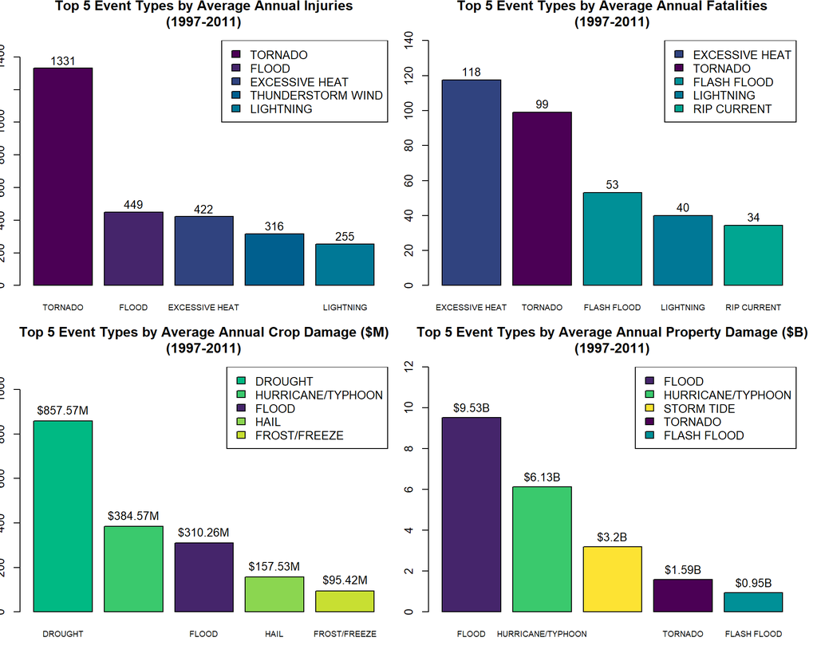

```r
library(dplyr)
library(lubridate)
library(ggplot2)
#Plot the Top 5 Event Types by Yearly Average <Effect> as a 2X2 grid of column charts
par(mfrow=c(2,2),pin=c(4.5,3))#   ,mai = c(.2,.2,.2,.2),omi = c(.2,.2,.2,.2))

# Make a table to loop through for the four charts needed with all variations
plot_index <- tibble(column = c("INJURIES","FATALITIES","CROPDMGTOT","PROPDMGTOT"),
                     friendly = c("Injuries","Fatalities","Crop Damage ($M)","Property Damage ($B)"),
                     scale = c(1,1,1e6,1e9),
                     digits = c(-2,-1,-2,0),
                     ylimadj = c(200,20,200,2),
                     textadj = c(50,5,50,0.5),
                     textrd = c(0,0,2,2),
                     text1 = c("","","$","$"),
                     text2 = c("","","M","B"))

for (i in 1:nrow(plot_index)){
    # Make a copy of the data for each plot type
    top5<-head(arrange(mean_eff_per_evtype, desc(!!as.name(plot_index$column[i]))),5)
    # Make the Bar Plot
    top5bar<- barplot(names.arg = top5$EVTYPE,
                      height = top5[[plot_index$column[i]]]/plot_index$scale[i],
                      beside = TRUE,
                      main = paste0("Top 5 Event Types by Average Annual ",
                                    plot_index$friendly[i],"\n(",max_year-14,"-",max_year,")"),
                      #ylab = paste0("Average Annual ",plot_index$friendly[i]),
                      xlab = "Event Type",
                      ylim = c(0, round(max(top5[[plot_index$column[i]]]/plot_index$scale[i]),
                                        digits = plot_index$digits[i]) + plot_index$ylimadj[i]),
                      col = top5$color,
                      cex.names = 0.7,
                      xpd = FALSE
                      )
    # Put the data labels at the top of each bar
    text(top5bar, top5[[plot_index$column[i]]]/plot_index$scale[i]+plot_index$textadj[i],
         paste0(plot_index$text1[i],round(top5[[plot_index$column[i]]]/plot_index$scale[i],
                                          digits = plot_index$textrd[i]),plot_index$text2[i]),cex=1)
    # Include a legend since some of the bar names at the bottom are too long and will get cut off
    legend("topright", legend = top5$EVTYPE, fill = top5$color)
}
```

Figure 1 - Top Five Event Types by Average Annual Health and Economic Effects

#### Effects Over Time for the Top 5 Event Types

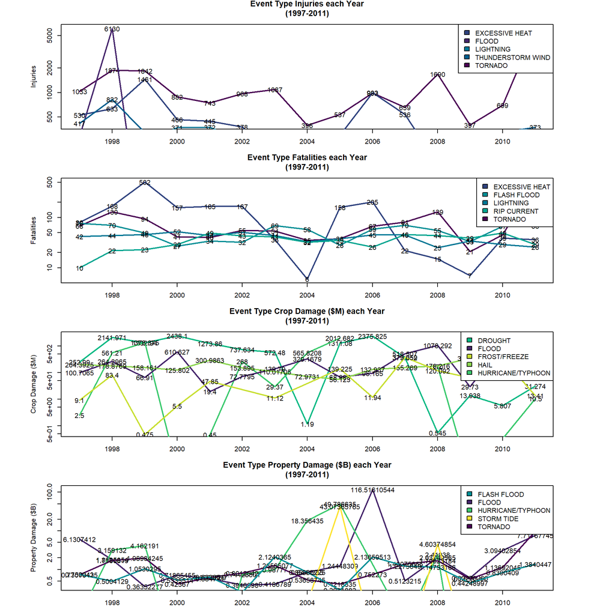

```r
library(dplyr)
library(lubridate)
library(ggplot2)
#Plot the Top 5 Event Types by Yearly Average <Effect> as a 2X2 grid of column charts
par(mfrow=c(4,1),pin=c(8,1.7),ylog=TRUE)#   ,mai = c(.2,.2,.2,.2),omi = c(.2,.2,.2,.2))

# Make a table to loop through for the four charts needed with all variations
plot_index <- tibble(column = c("INJURIES","FATALITIES","CROPDMGTOT","PROPDMGTOT"),
                     friendly = c("Injuries","Fatalities","Crop Damage ($M)","Property Damage ($B)"),
                     scale = c(1,1,1e6,1e9),
                     digits = c(-2,-1,-2,0),
                     ylimadj = c(200,20,200,2),
                     textadj = c(50,5,50,0.5),
                     textrd = c(0,0,2,2),
                     text1 = c("","","$","$"),
                     text2 = c("","","M","B"))

for (i in 1:nrow(plot_index)){
    # Make a copy of the data for each plot type
    top5evtypes<-head(arrange(mean_eff_per_evtype, desc(!!as.name(plot_index$column[i]))),5)$EVTYPE

    top5<-filter(eff_per_year, EVTYPE %in% top5evtypes)

    top5leg <- top5[!duplicated(top5[ , c("EVTYPE")]), ]

    firstline = TRUE

    for (evt in top5evtypes){
        top5f <- filter(top5, EVTYPE == evt)
        # Make the Line Plot
        if (firstline) {
            top5line<- plot(x = top5f$year,
                    y = top5f[[plot_index$column[i]]]/plot_index$scale[i],
                    main = paste0("Event Type ",plot_index$friendly[i]," each Year\n(",max_year-14,"-",max_year,")"),
                    ylab = plot_index$friendly[i],
                    xlab = "Year",
                    type = "l",
                    #ylim = c(0, round(max(top5[[plot_index$column[i]]]/plot_index$scale[i]),
                    #                  digits = plot_index$digits[i]) + plot_index$ylimadj[i]),
                    col = top5f$color,
                    lwd = 2,
                    log = "y",
                    #cex.names = 0.7,
                    xpd = FALSE
                    )
            firstline <- FALSE
        } else {

            lines(x = top5f$year,
                  y = top5f[[plot_index$column[i]]]/plot_index$scale[i],
                  col = top5f$color,
                  lwd = 2,
                  #log = "y"
                  )
        }


        # Put the data labels at each point
        text(top5f$year,
               top5f[[plot_index$column[i]]]/plot_index$scale[i],
               top5f[[plot_index$column[i]]]/plot_index$scale[i]
               )
        #text(top5line, top5f[[plot_index$column[i]]]/plot_index$scale[i]+plot_index$textadj[i],
        #     paste0(plot_index$text1[i],round(top5f[[plot_index$column[i]]]/plot_index$scale[i],
        #                                      digits = plot_index$textrd[i]),plot_index$text2[i]),cex=1)

    }
    # Include a legend since some of the bar names at the bottom are too long and will get cut off
    legend("topright", legend = top5leg$EVTYPE, fill = top5leg$color)
}
```

Figure 2 - Effects Over Time for the Top 5 Event Types